```r
source("aiuto.R")
source("FuncionHurwicz.R")
```

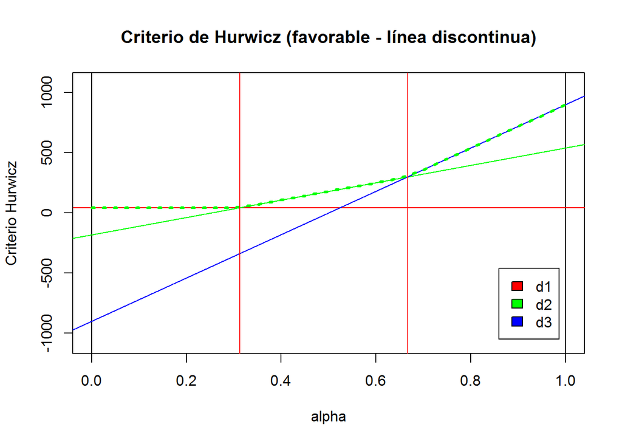

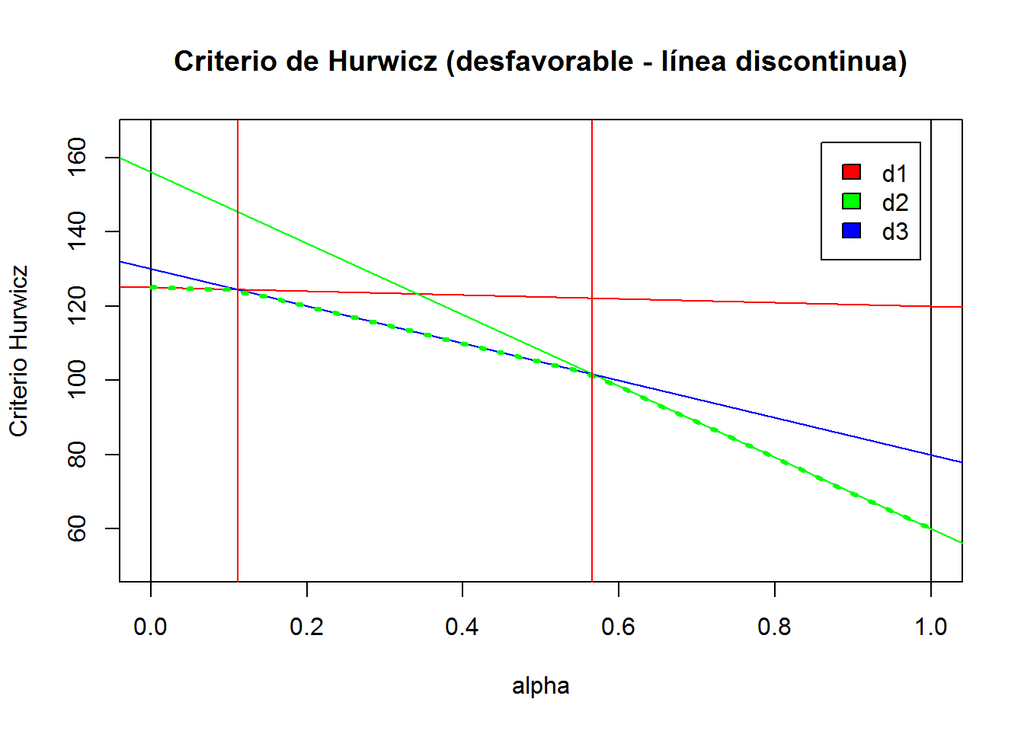

# Ejemplo 2

## Enunciado

La empresa S.T. se dedica a la fabricación y distribución de zapatillas. Tras los beneficios el año pasado, decide ampliar su oferta de mercado, pero duda con qué producto. Las alternativas son: formadores, botas y tacones. Para decantarse por uno u otro producto observará los beneficios (al mes) que genera cada opción y éstos dependerán de que la empresa firme un acuerdo con distribuidoras A , B o C. Los costes esperados son los siguientes: Si se firma el acuerdo con distribudoras A los beneficios de los formadores botas y tacones respectivamente son: 2000 €, 1800€ y 2300€. Si se firma el acuerdo con distribudoras B los beneficios de los formadores, botas y tacones respectivamente son: 1100 €, 500€ y 1000€. Si la empresa acepta firmar el acuerdo C los beneficios de los formadores, botas y tacones respectivamente son: 1900 €, 1500€ y 2700€. ¿con qué opción se beneficiará más la empresa?

```r
tb01 =  crea.tablaX(vector_matporfilas = c( 2000 , 1800 , 2300 ,
                                            1100 , 500 , 1000 ,
                                            1900 , 1500 , 2700 ), numalternativas = 3, numestados = 3)
tb01
```

```
##      e1   e2   e3
## d1 2000 1800 2300
## d2 1100  500 1000
## d3 1900 1500 2700
```

Tenemos que aplicar todos los criterios a esta tabla:

```r
Sol = criterio.Todos(tb01, alfa = 0.5, favorable = T)
Sol
```

```
##                   e1   e2   e3 Wald Optimista Hurwicz Savage Laplace
## d1              2000 1800 2300 1800      2300    2050    400  2033.3
## d2              1100  500 1000  500      1100     800   1700   866.7
## d3              1900 1500 2700 1500      2700    2100    300  2033.3
## iAlt.Opt (fav.) <NA> <NA> <NA>   d1        d3      d3     d3   d1,d3
##                 Punto Ideal
## d1                    400.0
## d2                   2321.6
## d3                    316.2
## iAlt.Opt (fav.)          d3
```

Ahora vamos a aplicar el Criterio de Hurwicz para distintos valores de alfa:

```r
solH = criterio.Hurwicz.General(tb01, alfa = 0.5, favorable = T)
solH
```

```
## $criterio
## [1] "Hurwicz"
##
## $alfa
## [1] 0.5
##
## $metodo
## [1] "favorable"
##
## $tablaX
##      e1   e2   e3
## d1 2000 1800 2300
## d2 1100  500 1000
## d3 1900 1500 2700
##
## $ValorAlternativas
##   d1   d2   d3
## 2050  800 2100
##
## $ValorOptimo
## [1] 2100
##
## $AlternativaOptima
## d3
##  3
```

```r
solH1 = criterio.Hurwicz.General(tb01, alfa = 0.3, favorable = T)
solH1
```

```
## $criterio
## [1] "Hurwicz"
##
## $alfa
## [1] 0.3
##
## $metodo
## [1] "favorable"
##
## $tablaX
##      e1   e2   e3
## d1 2000 1800 2300
## d2 1100  500 1000
## d3 1900 1500 2700
##
## $ValorAlternativas
##   d1   d2   d3
## 1950  680 1860
##
## $ValorOptimo
## [1] 1950
##
## $AlternativaOptima
## d1
##  1
```

```r
solH2 = criterio.Hurwicz.General(tb01, alfa = 0.7, favorable = T)
solH2
```

```
## $criterio
## [1] "Hurwicz"
##
## $alfa
## [1] 0.7
##
## $metodo
## [1] "favorable"
##
## $tablaX
##      e1   e2   e3
## d1 2000 1800 2300
## d2 1100  500 1000
## d3 1900 1500 2700
##
## $ValorAlternativas
##   d1   d2   d3
## 2150  920 2340
##
## $ValorOptimo
## [1] 2340
##
## $AlternativaOptima
## d3
##  3
```

#FUNCION DE EL GRUPO

```r
Intervalo= Hurwicz.intervalos(tb01, favorable = T)
```

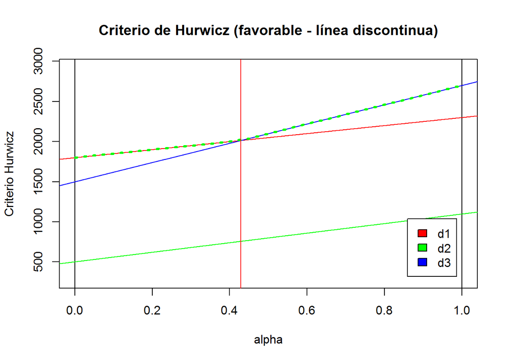

```r
Intervalo
```

```
## $AltOptimas
## [1] 1 3
##
## $PuntosDeCorte
## [1] 0.429
##
## $IntervalosAlfa
##      Intervalo       Alternativa
## [1,] "( 0 , 0.429 )" "1"
## [2,] "( 0.429 , 1 )" "3"
```